# Prosper Loan

## by Okebiorun Sarah

### Preliminary Wrangling

#### Introduction

This is a datset of Proser Loans that contains 113937 loans with 81 variables on each loan, including loan amount, borrower rate, current loan status, borrower income, and many others. We will use Python data science and data visualization libraries to explore the dataset’s variables and understand the data’s structure, patterns and relationships. We will also take our main findings from our exploration and convey them to others through an explanatory analysis.I'll be analyzing Univariate,Bivariate and Mulivariate analysis for a clearer understanding.

# Univariate Analysis

In this analysis,We'll be answering the following question

1. What the Borrower’s interest rate for prosper loan
2. The Borrower’s APR for prosper loan. Every borrower is concerned about the APR, he/she will be charged for the loan.
3. And lastly,does the borrower owns house at the time of listing (True & False)

Now let's our analysis answer the question.

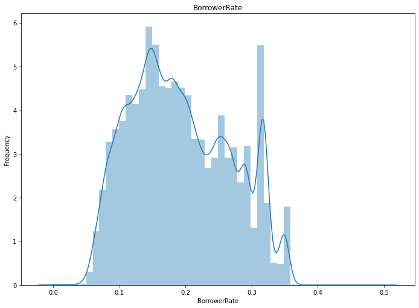

## What do you notice about the visualization?

From the above analysis,we can detect that the distribution isn't normal. But, what we can bring out from this is that our mean is 0.19 and the maximum borrowed rate is 0.49 and the minimum is 0.0. And the standard deviation for this analysis is 0.07.

Now, let's look for the analysis for the burrower APR.

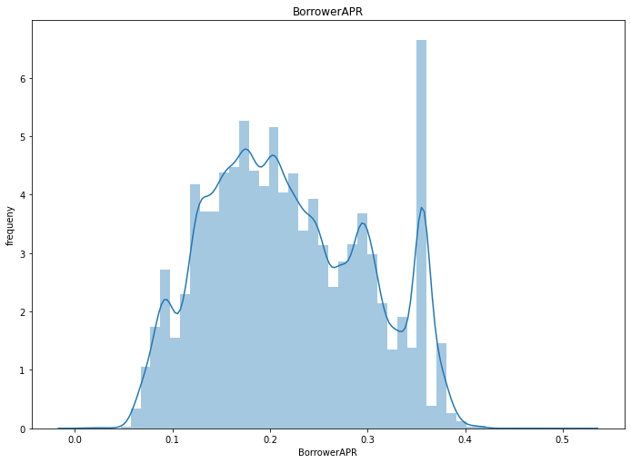

## What do you notice about the visualization?

From the above analysis,every borrower is concerned about the APR, he/she will be charged for the loan, so now from the analysis we can see that the average a person would be chargered for a loan is 0.2, the maximum would be 0.51 and the minimum would be 0.00. So, the mean of this analysis is 0.21 and the standard deviation of this analysis is 0.08.

Now, a question came to mind,and the question is, how many of this borrower are home owners? Let's use analysis to answer that.

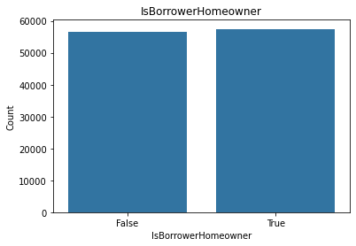

## What do you notice about the visualization?

So,now has this analysis answwered your question? From this analysis we can see that it's balanced, which implies that borrowers that have their own home are half and burrowers that does't have their own home are half.

# Bivariate Exploration

In this analysis, we would be finding the relationship between two entities,but,what question would be considered. Let's consider the following question

1. What the current type of employment of prosper rating
2. How worthy are the burrowers
3. Within the last 6 months how many borrowers make more frequent inquiries?
4. What is the APR for risky borrowers
5. How can we be sure that high risk borrowers must have higher BankCardUtilizaiton percentage.

Now let's consider those questions

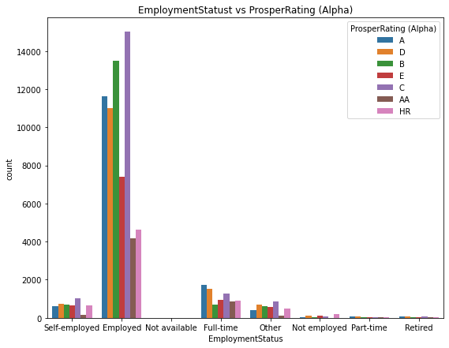

## What do you notice about the visualization?

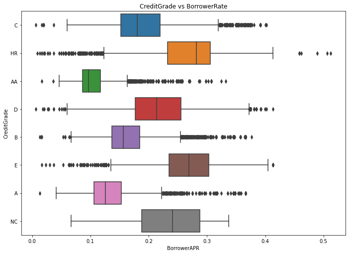

## What i notice about the visualization?

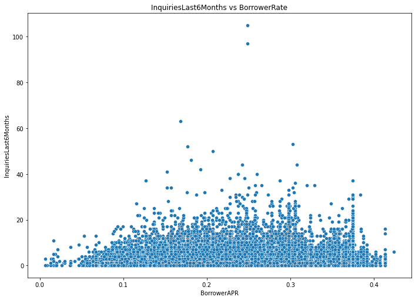

## What do you notice the visualization?

From the above scatter plot analysis we can see that within the last 6 month, we noticed that the borrowers who make more frequent inquiries would we charged higher APR, but we really don't have much difference.

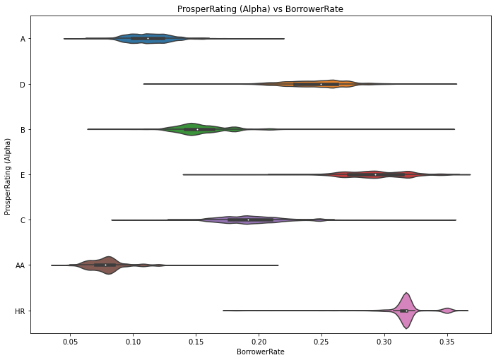

## What do you notice the visualization?

From this analysis,we can say that the APR for risky borrowers is significantly higher as compared to low risk borrowers

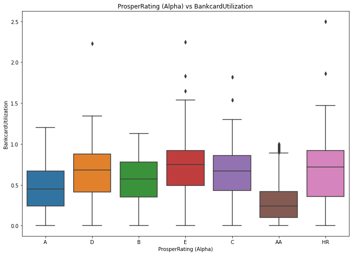

## What do you notice the visualization?

# Multivariate Exploration

In this analysis, we are going to be considering the following question

1. Is it possible for a borrowers to overspend and hence would need additional funds?
2. Would the size of loan amount between terms be bigger.

Let consider this

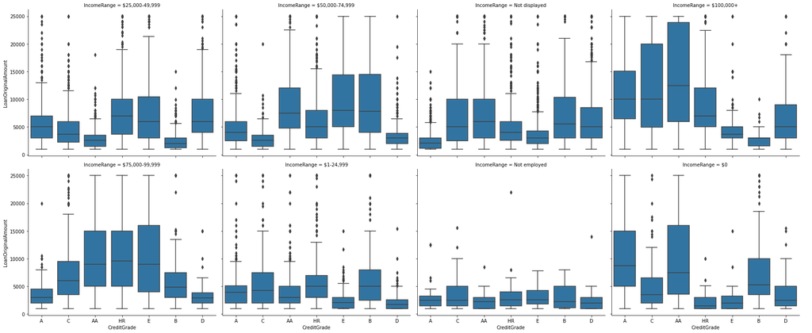

## What do you notice about the visualization?

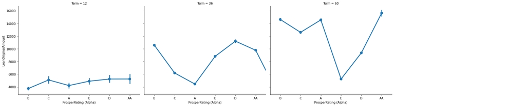

## What do you notice about the visualization?

# Conclusion

I got great practice in analysing a dataset, using seaborn for visualisations. I'm sure that with some more time, and, of course, some more learning, I could do better. But the purpose of this notebook was to sharpen my skills. So,far there's been a lot of struggles,but with the help of my course at udacity and futher research i was able to show some visualization.